# *Analisi della finanza nel cinema*

### *Obiettivo:*

Comprendere le dinamiche finanziarie dei film

### Argomenti trattati e domande poste:

- Cambierebbe l'andamento del budget e dell'incasso negli anni se si tenesse conto dell'inflazione? E cosa accomuna i diversi andamenti finanziari?
- I paesi che producono più film utilizzano budget più elevati? Come mai?
- I film con budget o incasso più elevati vantano una popolarità maggiore degli altri?

## *Dataset utilizzati*

1. Dataset con informazioni sui **film**:
   - Dati tecnici, dati finanziari, generi; aggiornato quotidianamente.

   Crediti: dataset di Asaniczka su kaggle.com. Link: [dataset_film](https://www.kaggle.com/datasets/asaniczka/tmdb-movies-dataset-2023-930k-movies).
2. Dataset sull'**inflazione**:
   - Indici di inflazione per anno; aggiornato al 2022.

   Crediti: dataset di Nell Gajare su kaggle.com. Link: [dataset_inflazione](https://www.kaggle.com/datasets/neelgajare/usa-cpi-inflation-from-19132022).
3. Shapefile con i poligoni dei **paesi** del mondo:
   - Rappresentazione visiva degli stati del mondo.

   Crediti: shapefile del sito [NaturalEarth.com](https://www.naturalearthdata.com). Link: [shapefile_paesi](https://www.naturalearthdata.com/downloads/110m-cultural-vectors/).

## Analisi di budget e incasso

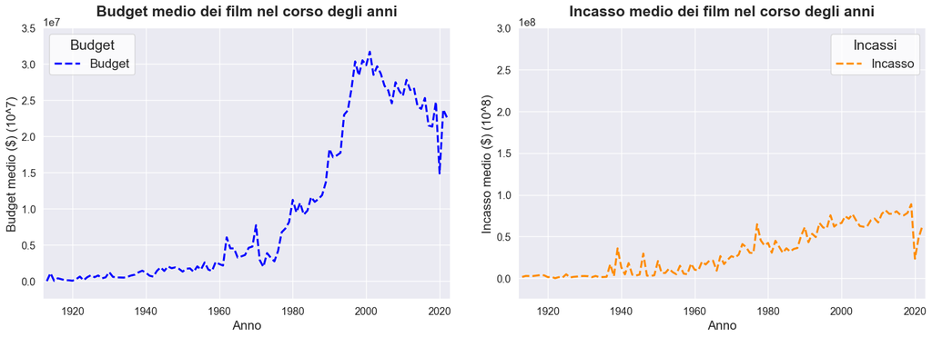

**Film con budget più alto**

| 2022 | Avatar:The Way of Water | 460.000.000 |
| --- | --- | --- |
| 2011 | Pirates of the Caribbean: On Stranger Tides | 379.000.000 |
| 2015 | Avengers: Age of Ultron | 365.000.000 |

**Film con incasso più alto**

| 2009 | Avatar | 2.923.706.026 |
| --- | --- | --- |
| 2019 | Avengers: Endgame | 2.800.000.000 |
| 2022 | Avatar: The Way of Water | 2.320.250.281 |

.

## Grafici che tengono conto dell'inflazione

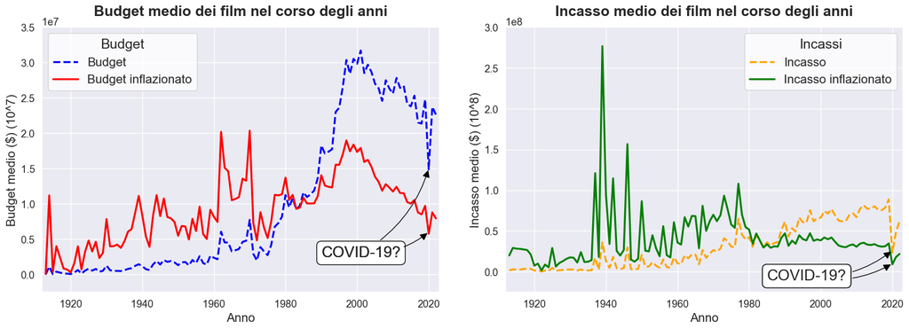

**Film con budget inflazionato più alto**

| 2011 | Pirates of the Caribbean: On Stranger Tides | 169.196.428 |
| --- | --- | --- |
| 2022 | Avatar: The Way of Water | 161.403.508 |
| 2015 | Avengers: Age of Ultron | 154.008.438 |

**Film con incasso inflazionato più alto**

| 1939 | Gone with the Wind | 3.095.019.838 |
| --- | --- | --- |
| 1946 | The Stranger | 1.694.736.842 |
| 1942 | Bambi | 1.671.544.687 |

.

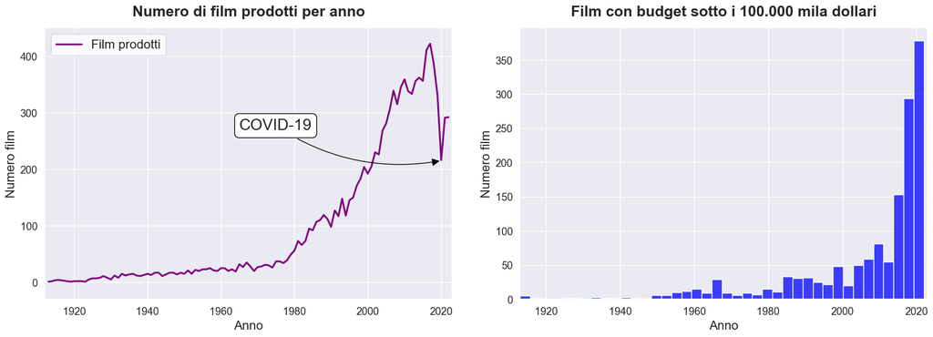

- Nel 2020 sono usciti il 35% in meno di film rispetto al 2019

## Quali film hanno budget maggiore?

[figure not shown]

- **1°** United States of America: 7147 film.
- **2°** United Kingdom: 1187 film.

.

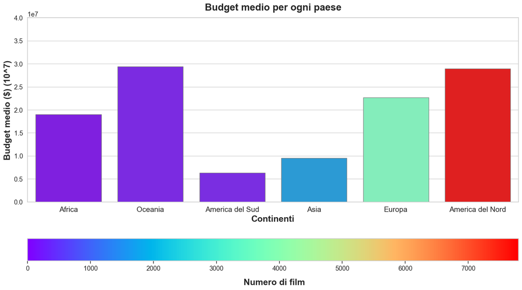

- **Oceania** ha il più alto budget medio (**29.422.243 $**), con numero di film prodotti: **243**

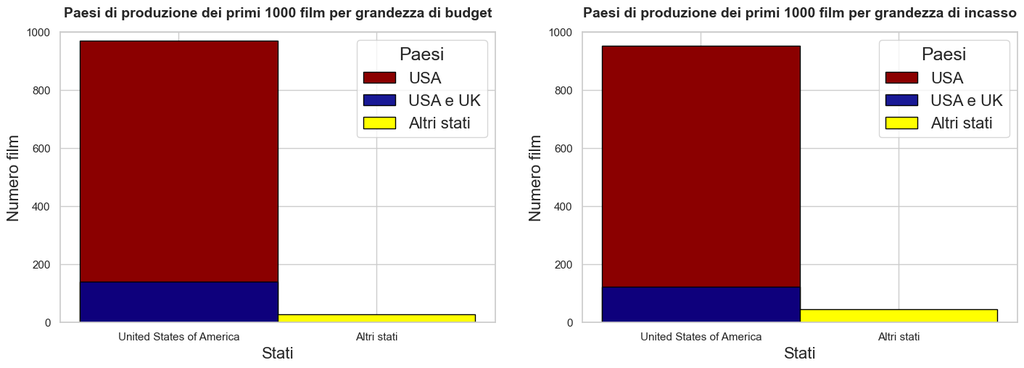

- Il **coefficiente di correlazione** tra budget e incasso è: **ρ = 0.806**
- Tra i film con **budget** più alto il **97.1%** è degli USA
- Tra i film con **incasso** più alto il **95.4%** è degli USA

## Film con maggiore popolarità

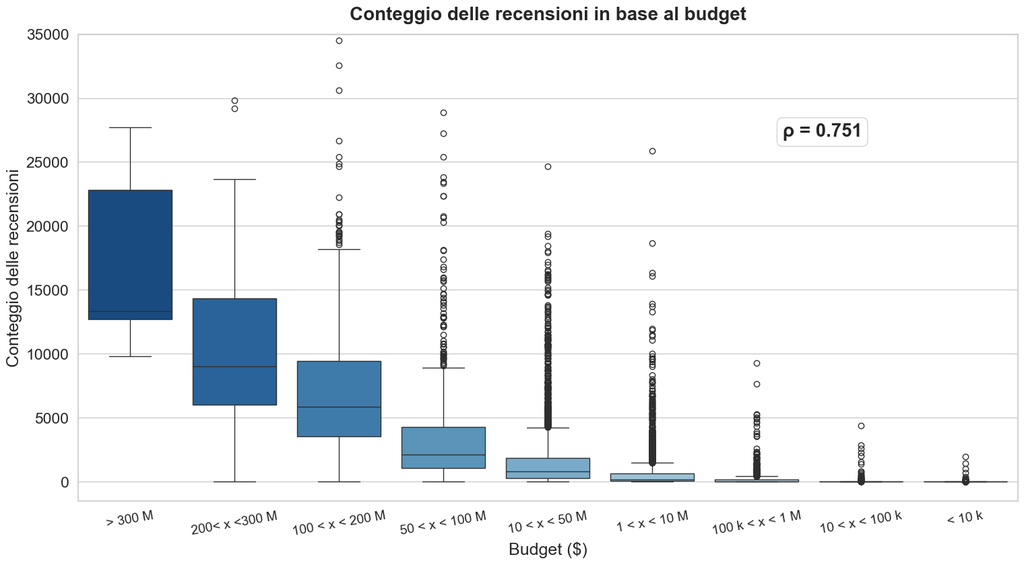

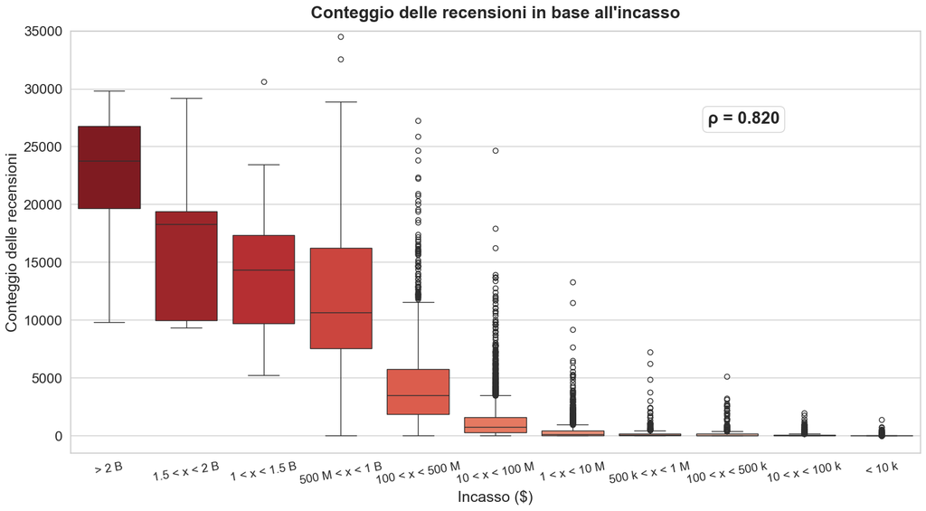

## *Conclusioni*

- Si nota una regressione negli anni delle performance finanziarie **medie**, nonostante i film con budget maggiore siano tutti degli ultimi 15 anni, poichè c'è stato un **aumento di film a basso budget** e il COVID-19 ha portato un **decadimento** di budget, incasso e film prodotti.
- Esiste una correlazione tra il livello di **budget** di un film, il suo rispettivo livello di **incasso** e il suo **paese** di produzione.
- Inoltre più sono **alti** il budget e l'incasso di un film e più questo acquisisce **popolarità**.